# tmppy4gnlj2

## 思想剧场：星空下的辩论会

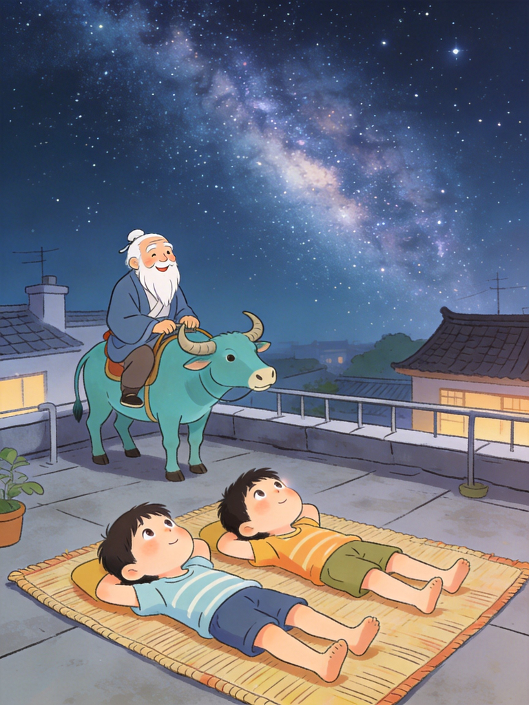

## 第一站：神话的创世想象

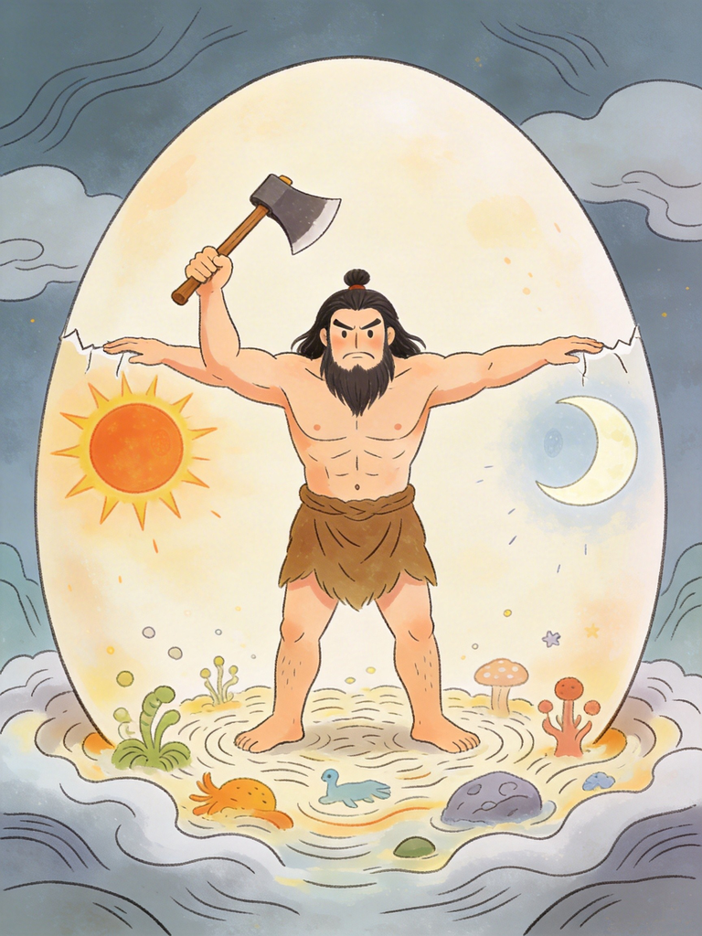

[figure not shown]

[figure not shown]

# 第一章 世界是从哪儿来的？

**时间**：一个夏夜，晚上九点  
**地点**：小区楼顶的天台  
**人物**：小星（10岁，爱问“为什么”的女孩）、小宇（11岁，喜欢编程的男孩） （幕起） 小星和小宇并排躺在凉席上，仰望着深邃的夜空。银河像一条洒满银粉的丝带，横跨天际。

**小星**：（指着北斗七星）你说，这些星星是从哪儿来的？它们一直就在那儿吗？

**小宇**：（推了推眼镜）科学老师说，宇宙是从一次“大爆炸”开始的。但我在想……“大爆炸”之前呢？总得有个“开始”的开始吧？

**老子**：（青牛停在旁边）你们俩的问题，两千五百年前也有人问过。

**小星**：（坐起来）老爷爷，那您知道答案吗？

**老子**：（微笑）我知道，但语言说不清。这样吧，我给你们几个线索——

**小宇**：（打断）等等！您怎么证明您说的是真的？万一是瞎猜的呢？

**老子**：（眼睛一亮）问得好！这正是哲学的开始——

**先质疑，再思考**。 **小星**：（举手）老爷爷，我有个问题！您说的“道”是不是就像我们学校门口的秋千？荡到最高点就会往回摆，这个规律不用谁规定，它自己就是这样运行的？

**老子**：（点头）很接近了！秋千的摆动规律是“道”在运动中的一个小小体现。

**小宇**：（皱眉）可是老爷爷，秋千的规律我们能测量和计算，您说的“道”看不见摸不着，怎么知道它不是我们想象出来的？就像我玩编程游戏时，有时会自己发明一些不存在的规则。

**老子**：（摸着胡子）问得妙！这正是哲学和科学的区别——科学测量能测到的，哲学思考那些测不到但可能存在的。你觉得“公平”能测量吗？“爱”能称重吗？但它们真实存在。

**小星**：（兴奋）我懂了！就像我们班选举班长，大家觉得小明最公平，这不是测量出来的，是大家感受到的。那“道”是不是也是一种感受？

**老子**：（微笑）感受是起点，思考是路径。你们已经踏上了哲学探险的第一步！ — 在还没有“科学”这个词的远古时代，我们的祖先用故事回答“世界从哪儿来”。 ### 盘古开天 -

**故事**：最初，宇宙像个混沌的大鸡蛋。巨人盘古在里面睡了一万八千年。醒来后，他用斧头劈开混沌——轻的气上升变成天，重的物质下沉变成地。盘古怕天地再合拢，就站在中间撑着。又过了一万八千年，天地稳固了，盘古却累倒了。他的身体化作万物：左眼变太阳，右眼变月亮，血液变江河，汗毛变草木…… -

**儿童比喻**：就像你用乐高搭了一个世界，最后连自己也变成了这个世界的一部分。 ### 女娲造人 -

**故事**：天地分开后，女神女娲觉得世界太安静了。她在黄河边用黄土和水，捏出了一个个小人。对着他们吹口气，小人们就活蹦乱跳起来。后来女娲累了，就用藤条沾泥水甩出去——溅落的泥点也变成了人。 -

**儿童比喻**：就像你既用心捏了几个最爱的玩偶，也用洒水壶“批量生产”了一群小伙伴。 ### 三个版本的对比 | 版本 | 核心想象 | 可能的bug | |——|———-|———–| | 中国盘古 | 巨人开辟，身体化万物 | “鸡蛋”外面是什么？盘古从哪儿来？ | | 印度梵天 | 梵分化出万物，同时解释等级 | 为什么分化就是不公平的等级？ | | 希腊卡俄斯 | 混沌中自然生出神 | 混沌为什么能“生”？ |

**小星的质疑**：这些故事听起来都很酷，但有个共同问题——它们都需要一个“开头”。如果盘古从鸡蛋里来，那鸡蛋从哪儿来？如果梵是一切，那梵从哪儿来？这不就像问“先有鸡还是先有蛋”，永远循环吗？

**老子的回应**：正是！所以我才说——

**世界可能从“无”中来**。 **小宇**：（举手）可是老爷爷，“无”怎么能生出“有”呢？就像我的零花钱是零元，怎么可能变出十块钱买冰淇淋？这说不通啊！

**老子**：（眼睛发亮）好问题！让我问你：你计划周末去公园玩，这个计划现在存在吗？它看不见摸不着，算是“无”吗？但它确实影响了你的期待和行动。从“无计划”到“有计划”，就是一种“无中生有”。

**小星**：（抢答）我明白了！就像我和好朋友吵架后和好，和好的“心意”原来不存在（“无”），但通过道歉和原谅，它就被创造出来了（“有”）！

**老子**：没错！你们用自己的生活经验理解了“无中生有”的精髓。

**小宇**：（突然想到）啊！我还有一个例子！就像我弟弟第一次学会分享玩具——他原来没有分享的念头（“无”），但看到我分享饼干给他，他就慢慢学会了，现在会主动分给我（“有”）。这也是从无到有吧？

**老子**：太棒了！你发现了“无中生有”在人和人之间的流动。分享的心意、道歉的勇气、原谅的智慧——这些都不是凭空出现，而是通过互动“生长”出来的。 — ### 古人说

**原文**： > 道生一，一生二，二生三，三生万物。  
> Dào shēng yī, yī shēng èr, èr shēng sān, sān shēng wànwù. **字词解释**： -

**道**🌟：宇宙最根本的规律、源头。不是具体的“路”，而是“为什么一切会这样运行”的原理。 - **一**：最初的、未分化的整体。 -

**二**：阴阳、天地、对立统一的两个方面。 -

**三**：阴阳互动产生的“新东西”。 -

**万物**：一切我们看到的世界。

**趣味比喻**： -

**道** = **游戏的底层代码**。你看不见它，但它决定了游戏里的一切规则：重力怎么作用、生命值怎么计算、白天黑夜怎么切换。 - **一生二** = 代码运行后，首先生成了“天”和“地”两个基本模块。 - **三生万物** = 天和地互动，产生了风雨、山川、植物、动物……最后才有了我们。

### 老子的神奇洞见 老子说：“**反者道之动**”——道的运动规律，总是向着相反方向转化。 - **例子**：你吹一个气球，吹到最大时（“极盛”），再吹就会“砰”一声破了（转向“破灭”）。冬天最冷时（“极寒”），春天就悄悄来了（转向“温暖”）。 -

**儿童体验**：荡秋千时，荡到最高点必然要往回摆；你跳得越高，落地时冲击也越大。这就是“反者道之动”在生活中的影子。 -

**生活共鸣点**：就像学校课间游戏——大家玩“一二三木头人”，有人觉得数数太快（“太严”），改成数慢一点；又有人觉得太慢（“太松”），再调整回适中。规则总是在“太严”和“太松”之间寻找平衡点，这就是“反者道之动”在人际关系中的体现。

**小星**：（歪头）老爷爷，我有个疑问！如果“反者道之动”总是向相反方向转化，那快乐会不会变成伤心？好朋友会不会变成敌人？这听起来有点可怕……

**老子**：（温和）你的担心很有道理。但“反者道之动”不是机械地“一定会变”，而是提醒我们：事情发展到极端时，就有变化的可能。知道这个规律，我们反而可以主动调节——快乐时懂得珍惜，难过时知道会过去；珍惜友谊，避免走到对立面。

**小宇的辩论回合**：可是老爷爷，如果道是代码，那写代码的“程序员”是谁？总得有个最初的设计者吧？

**老子**：（神秘一笑）这就是关键——

**道自己就是程序员**。它没有外部设计者，它自己设计自己。就像数学公式“1+1=2”不需要谁发明，它本身就是对的。 **小星**：（恍然大悟）哦！所以道是“自生自演”的规律，不是被创造的！ — ### 古人说

**原文**： > 五十而知天命。  
> Wǔshí ér zhī tiānmìng. **字词解释**： -

**天命**🌟：不是“老天命令你必须做什么”，而是“你生来最适合成为什么样的人、完成什么样的使命”。 - **知**：不是“知道一个答案”，而是“通过一辈子体验，慢慢理解”。

**趣味比喻**： -

**天命** = **人生游戏的主线任务**。你不是被强迫做这个任务，而是当你找到它时，会感到“啊，这就是我最想玩、也最擅长玩的关卡！” - **五十而知** = 就像你玩一个很长的游戏，可能要玩到第50个小时，才突然明白：“原来这个游戏真正想让我体验的是这个！”

### 孔子的“和而不同” 孔子说：“**君子和而不同，小人同而不和**。” - **解释**：真正厉害的人（君子），能和别人和谐相处，但保持自己的独特想法；只想讨好别人的人（小人），表面上一味附和，内心却并不和谐。 -

**儿童场景**： 1. 小组做手工时，小明想做飞船，小红想做城堡。最后他们决定：“我们做一个‘飞船城堡’——既能飞又有尖塔！”（这是“和而不同”） 2. 小华明明觉得应该用红色，但看到大家都选蓝色，就不敢说话了。（这是“同而不和”）

**小星的实践提问**：孔老师，我经常觉得和好朋友想法不一样，又怕吵架，怎么办？

**孔子**：（温和）记住三步：  
1. **先听**：认真听对方为什么这样想  
2. **再说**：清晰说你自己为什么那样想  
3. **共创**：找找有没有“第三选项”——既不是你的，也不是他的，而是你们共同创造的

**小宇的笔记**：这不就像编程时的“bug修复会议”嘛！不互相指责，一起找最优解。 — ## 想一想（互动升级版）

请你拿出笔，在书上空白处写下你的想法——没有对错，只有属于你的探险笔记！

### 问题一：宇宙像什么？请选出最符合你想法的比喻 - □ 一个不断膨胀的气球（像大爆炸理论） - □ 一套精密运转的程序（像老子的“道”） - □ 一位巨人做的巨大手工（像盘古神话） - □ 其他：________________（自己发明一个比喻！） **为什么选这个？**（写一句话理由）：________________________ ### 问题二：创造世界挑战赛 如果你要创造一个世界，必须按以下顺序设计（不能跳过）： | 顺序 | 项目 | 你的设计 | 为什么这样设计？ | |——|——|———-|——————| | ① | 一条最核心的规则 | 例如：“所有生命互相帮助” | 因为我想让这个世界充满温暖 | | ② | 第一批生命形式 | 例如：“会说话的动物和植物” | 想让世界一开始就有对话和故事 | | ③ | 一个自然现象 | 例如：“彩虹每次下雨后出现” | 想给世界增添惊喜和美感 | | ④ | 一个挑战性任务 | 例如：“每年一次‘创意大赛’” | 想让生命不断进步和创新 | ### 问题三：我的“天命”探测器升级版 **第一步：能量时间记录**  
回想过去一周，你做哪些事时，会觉得时间过得特别快、做完后心里特别充实？ | 活动 | 持续时间 | 充实感（1-5星） | 可能的天命线索 | |——|———-|—————–|—————–| | 例：帮同学解数学题 | 30分钟 | ★★★★★ | 喜欢分享知识，耐心解释 | | 你的发现1：__________ | __________ | __________ | __________ | | 你的发现2：__________ | __________ | __________ | __________ | | 你的发现3：__________ | __________ | __________ | __________ | **第二步：反问验证**  
问自己：如果做这件事没有报酬、没有人夸奖，我还愿意做吗？  
□ 愿意 □ 不愿意 □ 不确定 **第三步：未来想象**  
想象十年后，你还在做这件事，你希望它变成什么样？  
________________________ — ## 全球望远镜（深度对比版）

**当中国古人在思考“道”和“天命”时，世界其他地方在想什么？**

### 对比一：老子vs赫拉克利特（古希腊） | 维度 | 老子（中国） | 赫拉克利特（古希腊） | 一句话发现 | |——|————–|———————|————| | **核心概念** | 道（游戏的底层代码） | 逻各斯（像火一样的理性规律） | 都看到了世界既变动又有序 | | **运动规律** | 反者道之动（向相反转化） | 万物皆流，无物常驻 | 都强调变化是根本 | | **思维方式** | 整体、模糊、强调“无” | 逻辑、清晰、强调“有” | 中国偏整体模糊，西方偏分析清晰 | **对比点**： 老子和赫拉克利特都洞察到世界的变动性，但老子侧重“反向转化”的自然节律，赫拉克利特侧重“永恒流动”的逻辑规律。

**差异说明**： 中国思想像

**太极图**——黑白交融，你中有我；西方思想像**解剖图**——层层分解，界限清晰。这与文明土壤有关：中国农耕文明看重天时循环（道），希腊城邦文明看重公民辩论（逻各斯）。 **思考题**： 如果老子和赫拉克利特一起看日落，老子可能会说“日落是道的自然体现”，赫拉克利特可能会说“日落是火的元素转化”。你觉得哪个说法更有启发性？为什么？ ### 对比二：中国创世神话vs其他文明 | 文明 | 创世故事 | 儿童比喻 | 差异说明 | |——|———-|———-|———-| | 中国（盘古） | 巨人开辟，身体化万物 | 乐高搭建师变成自己的作品 | 强调“转化”而非“创造” | | 古希腊（卡俄斯） | 混沌中生出神 | 一锅汤里自动浮出食材 | 强调“自然生成” | | 古印度（梵天） | 梵分化出万物和等级 | 蛋糕切成不同大小的块 | 同时解释社会等级 |

**对比点**： 中国神话强调“牺牲转化”（盘古身体变万物），希腊神话强调“自然分化”（混沌自己生神），印度神话强调“预定结构”（梵分化为固定等级）。

**差异说明**： 这与三个文明的社会特点有关：中国重家庭传承（身体变子孙），希腊重个人自由（自然生发），印度重社会秩序（固定结构）。就像不同家庭的早餐习惯——中国家庭一锅粥大家分（转化），希腊家庭各自选面包（自然），印度家庭按长幼顺序取食（结构）。

**思考题**： 如果你要创造一个“理想世界”的神话，你会借鉴哪个版本？你会加入什么新元素？ 【视觉建议】 -

**简笔画地图**：一张世界地图简笔画，用不同颜色箭头从中国、希腊、印度指向中央的“创世故事大擂台”，每个箭头旁画简易图标：中国画巨人斧头，希腊画混沌漩涡，印度画等级阶梯。 -

**人物剪影**：老子与赫拉克利特侧影并列，老子身边画太极图，赫拉克利特身边画火焰与尺规。 — ## 实践练习：1章主题实践（可操作增强版）

### 任务目标 找到生活中三件“自己发生”的事，体会“道”的运行规律。 ### 材料准备 - 本练习记录表（可复印或手绘） - 一支笔 - 观察的眼睛和好奇的心 ### 版本选择说明 本练习提供两种版本，适合不同年龄和家庭情况的孩子： - **独立完成版**（适合11-12岁）：强调自主探索，培养独立思考能力。 - **亲子合作版**（适合8-10岁）：家长参与引导，在互动中理解哲学概念。 你可以根据实际情况选择一种版本完成，也可以先尝试独立版，再与家人合作完成合作版。 ### 独立完成版（适合11-12岁） #### 记录表格 | 观察日期 | 观察对象 | 它是如何“自己发生”的？ | 这让我联想到“道”的哪个特点？ | 我的感受 | |———-|———-|————————|——————————-|———-| | 例：4月1日 | 窗台上的多肉植物 | 没人浇水，但下雨后它自己吸收水分长出新叶 | 自然（不刻意） | 惊讶：原来生命这么聪明！ | | __________ | __________ | __________ | __________ | __________ | | __________ | __________ | __________ | __________ | __________ | | __________ | __________ | __________ | __________ | __________ | #### 具体步骤 **第一周：启动观察**  
1. **周一**：选择一个观察对象（如：一棵树、一盆花、天空的云、家里的宠物） 2.

**周二-周四**：每天花5分钟静静观察它（不干预、不打扰） 3.

**周五**：记录你的发现——它“自己”发生了什么变化？ 4.

**周六**：对照“道”的特点（自然、无、无名），找出匹配点 5.

**周日**：写下你的感受和疑问

**第二周：扩大观察**  
1. 换一个不同类型的观察对象（如：从植物→动物→自然现象） 2. 重复观察记录流程 3. 对比两个对象的“自己发生”方式有什么不同 **第三周：内化体验**  
1. 观察你自己——有哪些事是“自然想做”的？（如：看到朋友难过自然想安慰） 2. 记录这些“自然反应”带来的结果 3. 思考：这和“道”的运行有什么相通之处？ ### 亲子合作版（适合8-10岁） #### 家长引导指南 **亲子合作方案**： -

**初级**：和孩子一起选择一个观察对象，各自记录，周末分享发现 -

**中级**：设计“家庭道观察周”，全家观察不同对象，周五开“发现分享会” -

**高级**：将“道”的观察延伸到家庭决策——哪些事应该“自然发生”，哪些需要“适当干预”？

**常见问题应对**： - 孩子说“我什么都没发现”→ 提示：观察影子长短变化、树叶颜色渐变、宠物行为规律 - 孩子问“这有什么用”→ 回应：“不是所有事情都要‘有用’，观察本身就是乐趣，也是理解世界的方式” ### 完整完成样例 #### 独立完成版样例（学生小明，11岁）

**观察记录表（填写示例）** | 观察日期 | 观察对象 | 它是如何“自己发生”的？ | 这让我联想到“道”的哪个特点？ | 我的感受 | |———-|———-|————————|——————————-|———-| | 6月10日 | 小区池塘荷花 | 荷叶刚从水面露出，卷着的 | 无（尚未显现） | 好奇：它会怎么打开？ | | 6月12日 | 同一朵荷花 | 下雨后荷叶完全展开，有露珠 | 自然（不刻意） | 惊讶：雨水就是它的闹钟！ | | 6月14日 | 同一朵荷花 | 荷花苞出现，粉红色尖尖 | 反者道之动（从合到开） | 期待：快要开了！ | | 6月16日 | 同一朵荷花 | 荷花半开，蜜蜂绕飞 | 自然与生命互动 | 喜悦：生命在互相帮助！ | **三周实践总结** - **第一周**：观察荷花自然开放的过程，理解了“道”的自然性。 -

**第二周**：观察蚂蚁搬运食物，发现群体协作的“无名”规律。 -

**第三周**：观察自己帮助同学的自然反应，体会到“道”在人际关系中的体现。

**我的收获**： “道”不是神秘的东西，而是生活中无处不在的规律。当我学会观察和顺应这些规律时，做事更顺畅，心情也更轻松。就像荷花知道在雨后开放，我也在学着找到自己的“自然节奏”。 #### 亲子合作版样例（家庭实践）

**家庭观察周记录** - **孩子（8岁）观察**：多肉植物在阳光下叶子变红，阴天变绿。 -

**爸爸观察**：每天傍晚小区鸟叫声最密集，像在开“鸟民大会”。 -

**妈妈观察**：周末邻居家孩子笑声最多，工作日安静。

**家庭讨论要点**： 1. 这些现象有没有人为安排？（没有，都是自然发生） 2. 如果我们干预会怎样？（比如给多肉天天浇水→可能烂根） 3. 我们家的生活中有哪些“自然规律”？（如晚饭后全家放松时间） — — ## 智慧探险地图碎片 #1（升级版）

```
┌─────────────────────────────────────────────┐
│  第一章：世界是从哪儿来的？                │
├─────────────────────────────────────────────┤
│  🧭 探索路径                                │
│  • 从神话想象 → 哲学原理 → 人生意义        │
│  • 关键词题：起源必须有个“起点”吗？        │
├─────────────────────────────────────────────┤
│  👴 遇见智者                                │
│  • 老子——道（游戏的底层代码，反者道之动）  │
│  • 孔子——仁（人生主线任务，和而不同）      │
├─────────────────────────────────────────────┤
│  🛠️ 思想工具（带走这三个）                  │
│  1. “起源三假设”                           │
│     • 神创论（谁造神？）                   │
│     • 永恒存在（一直都有？）               │
│     • 道生万物（无中生有）                 │
│  2. “质疑三步法”                           │
│     • 先听对方说什么                       │
│     • 再问“为什么这样想”                   │
│     • 共同寻找“第三选项”                   │
│  3. “道观察记录表”                         │
│     • 每周观察一个对象                     │
│     • 记录自然发生的变化                   │
│     • 联想道的三个特点                     │
├─────────────────────────────────────────────┤
│  ❓ 留下你的问题（写在书边空白处）          │
│  • “如果道是无，无怎么能生出有？”          │
│  • “孔子的人道和老子的天道矛盾吗？”        │
│  • “我自己的‘天命’探测器准不准？”          │
└─────────────────────────────────────────────┘
```

## 下一章预告（悬念版）

**第二章：为什么我和别人不一样？**  
我们将进入一场**史上最激烈的人性辩论**： -